# R基础

R语言是比较常用的统计分析和绘图语言，拥有强大的统计库、绘图库和生信分析的Bioconductor库，是学习生物信息分析的必备语言之一。

## R安装

**Linux下安装**

如果使用的是新版的操作系统。直接可以用`sudo apt-get install r-base` 或者`yum install r-base`来安装。

若系统版本老，或没有根用户权限，则需要下载编译源码安装，最新地址为https://cran.r-project.org/src/base/R-latest.tar.gz。

具体编译方式为 (Linux下软件安装见 http://blog.genesino.com/2016/06/bash1):

```
# configure是收集系统信息，生成Makefile的过程
# --enable-R-shlib 需要设置，使得其他程序包括Rstudio可以使用R的动态库
# --prefix指定软件安装目录，需使用绝对路径
./configure --prefix=/home/ehbio/R/3.4.0 --enable-R-shlib

# 也可以使用这个命令，共享系统的blas库，提高运输速度
#./configure --prefix=/home/ehbio/R/3.4.0 --enable-R-shlib --with-blas --with-lapack

# make是编译的过程
make

# 安装到指定目录的过程
make install
```

安装完成之后，在Linux终端输入`R`即可启动交互式运行界面，`ctrl+d`退出`R`运行界面。若提示`找不到命令`，需要判断有没有加入进环境变量。

**Windows下安装**

下载 https://cran.r-project.org/bin/windows/双击就可以了。

两者都需要考虑环境变量，若有问题，见文后的参考。

## Rstudio基础

Rstudio是编辑、运行R语言的最为理想的工具之一，支持纯R脚本、Rmarkdown (脚本文档混排)、Bookdown (脚本文档混排成书)、Shiny (交互式网络应用)等。

### Rstudio版本

Rsdutio分为桌面版和服务器版，桌面版可以在单机使用，服务器版可以从浏览器访问供多人使用。

服务器版安装好之后，访问地址为<服务器IP:8787> (8787为默认端口号)，用户名和密码为Linux用户的用户名和密码。

### Rstudio安装

**Linux下安装服务器版**

安装参考 https://www.rstudio.com/products/rstudio/download-server/

```
wget https://download2.rstudio.org/rstudio-server-rhel-1.0.136-x86_64.rpm
sudo yum install --nogpgcheck rstudio-server-rhel-1.0.136-x86_64.rpm
```

安装完之后的检测、启动和配置

```
sudo rstudio-server verify-installation #查看是否安装正确
sudo rstudio-server start ## 启动
sudo rstudio-server status ## 查看状态
sudo rstudio-server stop ## 停止
ifconfig | grep 'inet addr' ## 查看服务端ip地址
```

**Windows下安装桌面版**

下载之后 (https://www.rstudio.com/products/rstudio/download2/)双击安装，需要使用**管理员权限**，其它无需要注意的。

## R基本语法

### 获取帮助文档，查看命令或函数的使用方法、事例或适用范围

```r
>>> ?command
>>> ??command #深度搜索或模糊搜索此命令

>>> example(command) #得到命令的例子

>>> example(plot)
```

### R中的变量及其初始化

```r
# Windows下运行，如果出现
# Warning message:
# In strsplit(code, "\n", fixed = TRUE) :
#  input string 1 is invalid in this locale
# 则运行此句。
# Linux下不需要。
Sys.setlocale('LC_ALL','C')
```

```
## [1] "C"
```

```r
# 数字变量
a <- 10
a
```

```
## [1] 10
```

```r
# 字符串变量
# 必须用引号括起来
a <- "abc"
a
```

```
## [1] "abc"
```

```r
# 逻辑变量
a <- TRUE
a
```

```
## [1] TRUE
```

```r
# 也表示TRUE
b <- T
b
```

```
## [1] TRUE
```

```r
# FALSE，同F
d <- FALSE
d
```

```
## [1] FALSE
```

向量，vector，存储相同的数据类型。如果有字符型元素，所有元素都转换为字符型。

```r
# 向量
a <- vector(mode="logical", length=5)
a
```

```
## [1] FALSE FALSE FALSE FALSE FALSE
```

```r
a <- c(1,2,3,4)
# 判断一个变量是不是vector
is.vector(a)
```

```
## [1] TRUE
```

```r
is.atomic(a)
```

```
## [1] TRUE
```

因子，factor，节省存储空间的特殊类型，适用于重复值特别多时。每个原值只存储一份，在原数据中用数字表示。 去重后的原值被称为水平 (level)，可以修改顺序。绘图时调整顺序就是使用的这个。

```r
a <- c('y','i','s','h','e','n','g','x','i','n')
b <- as.factor(a)
# 注意levels默认是字母顺序
b
```

```
##  [1] y i s h e n g x i n
## Levels: e g h i n s x y
```

更改因子的顺序

```r
# 设置levels
b <- factor(a,
        levels=c("y","x","s","e","g","i","h","n"),
        ordered=T)
b
```

```
##  [1] y i s h e n g x i n
## Levels: y < x < s < e < g < i < h < n
```

列表，list，不同类型的变量组合在一起，常用于存储各种复杂类型函数或绘图的输出。

```r
ysx_list <- list(web="www.ehbio.com/Training",
        staff=c("LYX","CL","ZX","CT"),
        contentL=list(R=c("basic","plot"),
                      Linux=c("basic","windows")))
ysx_list
```

```
## $web
## [1] "www.ehbio.com/Training"
##
## $staff
## [1] "LYX" "CL"  "ZX"  "CT"
##
## $contentL
## $contentL$R
## [1] "basic" "plot"
##
## $contentL$Linux
## [1] "basic"   "windows"
```

- str(list_name) 可以查看列表的结构，方便索引获得对应的元素。
- list_name$list_subname提取对应子元素。
- 注意单方括号和双方括号的区别，一个取出子列表，一个取出子列表的元素。

```r
str(ysx_list)
```

```
## List of 3
##  $ web     : chr "www.ehbio.com/Training"
##  $ staff   : chr [1:4] "LYX" "CL" "ZX" "CT"
##  $ contentL:List of 2
##   ..$ R    : chr [1:2] "basic" "plot"
##   ..$ Linux: chr [1:2] "basic" "windows"
```

```r
ysx_list$web
```

```
## [1] "www.ehbio.com/Training"
```

```r
ysx_list$contentL$R
```

```
## [1] "basic" "plot"
```

```r
ysx_list[1]
```

```
## $web
## [1] "www.ehbio.com/Training"
```

```r
ysx_list[[1]]
```

```
## [1] "www.ehbio.com/Training"
```

矩阵，matrix，二维的array，所有元素都是相同类型。可以按照[row, col]索引。

```r
# 矩阵
a <- matrix(1:20,nrow=5,ncol=4,byrow=T)
a
```

```
##      [,1] [,2] [,3] [,4]
## [1,]    1    2    3    4
## [2,]    5    6    7    8
## [3,]    9   10   11   12
## [4,]   13   14   15   16
## [5,]   17   18   19   20
```

```r
is.matrix(a)
```

```
## [1] TRUE
```

```r
dim(a) #查看或设置数组的维度向量
```

```
## [1] 5 4
```

```r
print(paste("矩阵a的行数", nrow(a)))
```

```
## [1] "矩阵a的行数 5"
```

```r
print(paste("矩阵a的列数", ncol(a)))
```

```
## [1] "矩阵a的列数 4"
```

```r
#查看或设置行列名
rownames(a)
```

```r
rownames(a) <- c('a','b','c','d','e')
a
```

```
##   [,1] [,2] [,3] [,4]
## a    1    2    3    4
## b    5    6    7    8
## c    9   10   11   12
## d   13   14   15   16
## e   17   18   19   20
```

```r
# R中获取一系列的字母
letters[1:4]
```

```
## [1] "a" "b" "c" "d"
```

```r
colnames(a) <- letters[1:4]
a
```

```
##    a  b  c  d
## a  1  2  3  4
## b  5  6  7  8
## c  9 10 11 12
## d 13 14 15 16
## e 17 18 19 20
```

### 变量类型和转换

不同的变量类型有不同的操作方式，`is`系列和`as`系列函数用来判断变量的属性和转换变量的属性

```r
is.character(a)
```

```
## [1] FALSE
```

```r
is.numeric(a)
```

```
## [1] TRUE
```

```r
is.matrix(a)
```

```
## [1] TRUE
```

```r
is.data.frame(a)
```

```
## [1] FALSE
```

```r
is.data.frame(as.data.frame(a))
```

```
## [1] TRUE
```

### R中矩阵运算

```r
set.seed(101)
a <- round(rnorm(40),2)
a
```

```
##  [1] -0.33  0.55 -0.67  0.21  0.31  1.17  0.62 -0.11  0.92 -0.22  0.53
## [12] -0.79  1.43 -1.47 -0.24 -0.19 -0.85  0.06 -0.82 -2.05 -0.16  0.71
## [23] -0.27 -1.46  0.74 -1.41  0.47 -0.12  0.47  0.50  0.89  0.28  1.01
## [34] -2.07  1.19 -0.72  0.17  0.92 -1.67  0.45
```

```r
# ncol=5 5列
# byrow=T: 先填充行
a <- matrix(a, ncol=5, byrow=T)
a
```

```
##       [,1]  [,2]  [,3]  [,4]  [,5]
## [1,] -0.33  0.55 -0.67  0.21  0.31
## [2,]  1.17  0.62 -0.11  0.92 -0.22
## [3,]  0.53 -0.79  1.43 -1.47 -0.24
## [4,] -0.19 -0.85  0.06 -0.82 -2.05
## [5,] -0.16  0.71 -0.27 -1.46  0.74
## [6,] -1.41  0.47 -0.12  0.47  0.50
## [7,]  0.89  0.28  1.01 -2.07  1.19
## [8,] -0.72  0.17  0.92 -1.67  0.45
```

```r
# 按行加和
rowSums(a)
```

```
## [1]  0.07  2.38 -0.54 -3.85 -0.44 -0.09  1.30 -0.85
```

```r
# 注意检查括号的配对
#a <- a[rowSums(abs(a)!=0,]
#错误: 意外的']' in "a <- a[rowSums(abs(a)!=0,]"

# 去除全部为0的行
a <- a[rowSums(a)!=0,]

# 另外一种方式去除全部为0的行
#a[rowSums(a==0)<ncol(a),]

a
```

```
##       [,1]  [,2]  [,3]  [,4]  [,5]
## [1,] -0.33  0.55 -0.67  0.21  0.31
## [2,]  1.17  0.62 -0.11  0.92 -0.22
## [3,]  0.53 -0.79  1.43 -1.47 -0.24
## [4,] -0.19 -0.85  0.06 -0.82 -2.05
## [5,] -0.16  0.71 -0.27 -1.46  0.74
## [6,] -1.41  0.47 -0.12  0.47  0.50
## [7,]  0.89  0.28  1.01 -2.07  1.19
## [8,] -0.72  0.17  0.92 -1.67  0.45
```

矩阵运算，R默认针对整个数据进行常见运算

```r
#所有值都乘以2
a * 2
```

```
##       [,1]  [,2]  [,3]  [,4]  [,5]
## [1,] -0.66  1.10 -1.34  0.42  0.62
## [2,]  2.34  1.24 -0.22  1.84 -0.44
## [3,]  1.06 -1.58  2.86 -2.94 -0.48
## [4,] -0.38 -1.70  0.12 -1.64 -4.10
## [5,] -0.32  1.42 -0.54 -2.92  1.48
## [6,] -2.82  0.94 -0.24  0.94  1.00
## [7,]  1.78  0.56  2.02 -4.14  2.38
## [8,] -1.44  0.34  1.84 -3.34  0.90
```

```r
# 所有值取绝对值，再取对数 （取对数前一般加一个数避免对0或负值取对数）
log2(abs(a)+1)
```

```
##           [,1]      [,2]       [,3]      [,4]      [,5]
## [1,] 0.4114262 0.6322682 0.73984810 0.2750070 0.3895668
## [2,] 1.1176950 0.6959938 0.15055968 0.9411063 0.2868811
## [3,] 0.6135317 0.8399596 1.28095631 1.3045110 0.3103401
## [4,] 0.2509616 0.8875253 0.08406426 0.8639385 1.6088092
## [5,] 0.2141248 0.7739963 0.34482850 1.2986583 0.7990873
## [6,] 1.2690331 0.5558162 0.16349873 0.5558162 0.5849625
## [7,] 0.9183862 0.3561438 1.00719550 1.6182387 1.1309309
## [8,] 0.7824086 0.2265085 0.94110631 1.4168397 0.5360529
```

```r
# 取出最大值、最小值、行数、列数
max(a)
```

```
## [1] 1.43
```

```r
min(a)
```

```
## [1] -2.07
```

```r
nrow(a)
```

```
## [1] 8
```

```r
ncol(a)
```

```
## [1] 5
```

```r
# 计算每一行的var (方差)
# apply表示对数据（第一个参数）的每一行 (第二个参数赋值为1) 或每一列 (2)操作
#      最后返回一个列表
apply(a,1,var)
```

```
## [1] 0.24988 0.38183 1.27752 0.66815 0.81077 0.67317 1.81340 1.06015
```

```r
# 计算每一行的mad (中值绝对偏差)
# 一般认为比方差的鲁棒性更强，更少受异常值的影响，更能反映数据间的差异)
# 函数中的第二个参数 1 表示安行操作
apply(a,1,mad)
```

```
## [1] 0.504084 0.815430 1.141602 0.934038 1.289862 0.044478 0.444780 1.111950
```

```r
# 计算每一列的平均值
apply(a,2,mean)
```

```
## [1] -0.02750  0.14500  0.28125 -0.73625  0.08500
```

```r
# 取出中值绝对偏差大于0.5的行
b = a[apply(a,1,mad)>0.5,]
b
```

```
##       [,1]  [,2]  [,3]  [,4]  [,5]
## [1,] -0.33  0.55 -0.67  0.21  0.31
## [2,]  1.17  0.62 -0.11  0.92 -0.22
## [3,]  0.53 -0.79  1.43 -1.47 -0.24
## [4,] -0.19 -0.85  0.06 -0.82 -2.05
## [5,] -0.16  0.71 -0.27 -1.46  0.74
## [6,] -0.72  0.17  0.92 -1.67  0.45
```

```r
# 输出 1 4 2 3 5
# 解释：原列表第一个元素显示在第一位
#       原列表第四个元素显示在第二位
#       原列表第二个元素显示在第三位
order(c(1,3,4,2,5))
```

```
## [1] 1 4 2 3 5
```

```r
# 产生新的顺序
#
order(apply(b,1,mad), decreasing=T)
```

```
## [1] 5 3 6 4 2 1
```

```r
# 矩阵按照mad的大小降序排列
c = b[order(apply(b,1,mad), decreasing=T),]
c
```

```
##       [,1]  [,2]  [,3]  [,4]  [,5]
## [1,] -0.16  0.71 -0.27 -1.46  0.74
## [2,]  0.53 -0.79  1.43 -1.47 -0.24
## [3,] -0.72  0.17  0.92 -1.67  0.45
## [4,] -0.19 -0.85  0.06 -0.82 -2.05
## [5,]  1.17  0.62 -0.11  0.92 -0.22
## [6,] -0.33  0.55 -0.67  0.21  0.31
```

```r
rownames(c) <- paste('Gene', letters[1:nrow(c)], sep="_")
colnames(c) <- toupper(letters[1:ncol(c)])
c
```

```
##            A     B     C     D     E
## Gene_a -0.16  0.71 -0.27 -1.46  0.74
## Gene_b  0.53 -0.79  1.43 -1.47 -0.24
## Gene_c -0.72  0.17  0.92 -1.67  0.45
## Gene_d -0.19 -0.85  0.06 -0.82 -2.05
## Gene_e  1.17  0.62 -0.11  0.92 -0.22
## Gene_f -0.33  0.55 -0.67  0.21  0.31
```

```r
# 矩阵转置
expr = t(c)
expr
```

```
##   Gene_a Gene_b Gene_c Gene_d Gene_e Gene_f
## A  -0.16   0.53  -0.72  -0.19   1.17  -0.33
## B   0.71  -0.79   0.17  -0.85   0.62   0.55
## C  -0.27   1.43   0.92   0.06  -0.11  -0.67
## D  -1.46  -1.47  -1.67  -0.82   0.92   0.21
## E   0.74  -0.24   0.45  -2.05  -0.22   0.31
```

```r
# 矩阵值的替换
expr2 = expr
expr2[expr2<0] = 0
expr2
```

```
##   Gene_a Gene_b Gene_c Gene_d Gene_e Gene_f
## A   0.00   0.53   0.00   0.00   1.17   0.00
## B   0.71   0.00   0.17   0.00   0.62   0.55
## C   0.00   1.43   0.92   0.06   0.00   0.00
## D   0.00   0.00   0.00   0.00   0.92   0.21
## E   0.74   0.00   0.45   0.00   0.00   0.31
```

```r
# 矩阵中只针对某一列替换
# expr2是个矩阵不是数据框，不能使用列名字索引
# expr2[expr2$Gene_b<1, "Gene_b"] <- 1
```

```r
# str是一个最为常用、好用的查看变量信息的工具，尤其是对特别复杂的变量，
#    可以看清其层级结构，便于提取数据
str(expr2)
```

```
##  num [1:5, 1:6] 0 0.71 0 0 0.74 0.53 0 1.43 0 0 ...
##  - attr(*, "dimnames")=List of 2
##   ..$ : chr [1:5] "A" "B" "C" "D" ...
##   ..$ : chr [1:6] "Gene_a" "Gene_b" "Gene_c" "Gene_d" ...
```

数据框，dataframe，子列表长度一致的特殊list，具有list和matrix的双重特性，通常与matrix可互换。 若在程序运行时碰到”’x’ must be matrix”，需要做下as.matrix转换；若是”’x’ must be data.frame”，需要做下as.data.frame转换。这里的x是你提供的数据变量。

```r
# 转换为数据框，再进行相应的操作
expr2 <- as.data.frame(expr2)
str(expr2)
```

```
## 'data.frame':    5 obs. of  6 variables:
##  $ Gene_a: num  0 0.71 0 0 0.74
##  $ Gene_b: num  0.53 0 1.43 0 0
##  $ Gene_c: num  0 0.17 0.92 0 0.45
##  $ Gene_d: num  0 0 0.06 0 0
##  $ Gene_e: num  1.17 0.62 0 0.92 0
##  $ Gene_f: num  0 0.55 0 0.21 0.31
```

```r
expr2[expr2$Gene_b<1, "Gene_b"] <- 1
expr2
```

```
##   Gene_a Gene_b Gene_c Gene_d Gene_e Gene_f
## A   0.00   1.00   0.00   0.00   1.17   0.00
## B   0.71   1.00   0.17   0.00   0.62   0.55
## C   0.00   1.43   0.92   0.06   0.00   0.00
## D   0.00   1.00   0.00   0.00   0.92   0.21
## E   0.74   1.00   0.45   0.00   0.00   0.31
```

### R中矩阵筛选合并

```r
# 读入样品信息
sampleInfo = "Samp;Group;Genotype
A;Control;WT
B;Control;WT
D;Treatment;Mutant
C;Treatment;Mutant
E;Treatment;WT
F;Treatment;WT"

phenoData = read.table(text=sampleInfo,sep=";", header=T, row.names=1, quote="")
phenoData
```

```
##       Group Genotype
## A   Control       WT
## B   Control       WT
## D Treatment   Mutant
## C Treatment   Mutant
## E Treatment       WT
## F Treatment       WT
```

```r
# 把样品信息按照基因表达矩阵中的样品信息排序，并只保留有基因表达信息的样品
# ‘%in%’ is a more intuitive interface as a binary operator, which
#     returns a logical vector indicating if there is a match or not for
#     its left operand.

phenoData = phenoData[rownames(phenoData) %in% rownames(expr),]
phenoData
```

```
##       Group Genotype
## A   Control       WT
## B   Control       WT
## D Treatment   Mutant
## C Treatment   Mutant
## E Treatment       WT
```

```r
# 合并矩阵
# by=0 表示按照行的名字排序
# by=columnname 表示按照共有的某一列合并
# 合并后多出了新的一列Row.names
merge_data = merge(expr, phenoData, by=0, all.x=T)
merge_data
```

```
##   Row.names Gene_a Gene_b Gene_c Gene_d Gene_e Gene_f     Group Genotype
## 1         A  -0.16   0.53  -0.72  -0.19   1.17  -0.33   Control       WT
## 2         B   0.71  -0.79   0.17  -0.85   0.62   0.55   Control       WT
## 3         C  -0.27   1.43   0.92   0.06  -0.11  -0.67 Treatment   Mutant
## 4         D  -1.46  -1.47  -1.67  -0.82   0.92   0.21 Treatment   Mutant
## 5         E   0.74  -0.24   0.45  -2.05  -0.22   0.31 Treatment       WT
```

```r
rownames(merge_data) <- merge_data$Row.names
merge_data
```

```
##   Row.names Gene_a Gene_b Gene_c Gene_d Gene_e Gene_f     Group Genotype
## A         A  -0.16   0.53  -0.72  -0.19   1.17  -0.33   Control       WT
## B         B   0.71  -0.79   0.17  -0.85   0.62   0.55   Control       WT
## C         C  -0.27   1.43   0.92   0.06  -0.11  -0.67 Treatment   Mutant
## D         D  -1.46  -1.47  -1.67  -0.82   0.92   0.21 Treatment   Mutant
## E         E   0.74  -0.24   0.45  -2.05  -0.22   0.31 Treatment       WT
```

```r
# 去除一列；-1表示去除第一列
merge_data = merge_data[,-1]
merge_data
```

```
##   Gene_a Gene_b Gene_c Gene_d Gene_e Gene_f     Group Genotype
## A  -0.16   0.53  -0.72  -0.19   1.17  -0.33   Control       WT
## B   0.71  -0.79   0.17  -0.85   0.62   0.55   Control       WT
## C  -0.27   1.43   0.92   0.06  -0.11  -0.67 Treatment   Mutant
## D  -1.46  -1.47  -1.67  -0.82   0.92   0.21 Treatment   Mutant
## E   0.74  -0.24   0.45  -2.05  -0.22   0.31 Treatment       WT
```

```r
write.table(merge_data, file="mergedata.txt", sep="\t", quote = F, col.names=T, row.names=T)
```

```r
# 提取出所有的数值列
merge_data[sapply(merge_data, is.numeric)]
```

```
##   Gene_a Gene_b Gene_c Gene_d Gene_e Gene_f
## A  -0.16   0.53  -0.72  -0.19   1.17  -0.33
## B   0.71  -0.79   0.17  -0.85   0.62   0.55
## C  -0.27   1.43   0.92   0.06  -0.11  -0.67
## D  -1.46  -1.47  -1.67  -0.82   0.92   0.21
## E   0.74  -0.24   0.45  -2.05  -0.22   0.31
```

### `str`的应用

`str`: Compactly display the internal *str*ucture of an R object, a diagnostic function and an alternative to ‘summary (and to some extent, ’dput’). Ideally, only one line for each ‘basic’ structure is displayed. It is especially well suited to compactly display the (abbreviated) contents of (possibly nested) lists. The idea is to give reasonable output for *any* R object. It calls ‘args’ for (non-primitive) function objects.

`str`用来告诉结果的构成方式，对于不少Bioconductor的包，或者复杂的R函数的输出，都是一堆列表的嵌套，`str(complex_result)`会输出每个列表的名字，方便提取对应的信息。

```r
# str的一个应用例子
str(list(a = "A", L = as.list(1:100)), list.len = 9)
```

```
## List of 2
##  $ a: chr "A"
##  $ L:List of 100
##   ..$ : int 1
##   ..$ : int 2
##   ..$ : int 3
##   ..$ : int 4
##   ..$ : int 5
##   ..$ : int 6
##   ..$ : int 7
##   ..$ : int 8
##   ..$ : int 9
##   .. [list output truncated]
```

利用`str`查看`pca`的结果，具体的`PCA`应用查看 http://mp.weixin.qq.com/s/sRElBMkyR9rGa4TQp9KjNQ。

```r
pca_result <- prcomp(expr)
pca_result
```

```
## Standard deviations (1, .., p=5):
## [1] 1.570055e+00 1.231840e+00 5.672809e-01 3.794601e-01 2.491372e-17
##
## Rotation (n x k) = (6 x 5):
##                PC1        PC2          PC3        PC4         PC5
## Gene_a -0.34355451  0.5001920  0.650147830  0.1696397  0.31171383
## Gene_b -0.62754188 -0.4212266 -0.009015055  0.5102353  0.09468875
## Gene_c -0.61583558  0.2380695 -0.090552886 -0.5043097 -0.54634259
## Gene_d -0.09466619 -0.6006028  0.375560791 -0.6083885  0.33661426
## Gene_e  0.26886835 -0.2144014  0.633472755  0.1814146 -0.65536605
## Gene_f  0.16630136  0.3301628  0.163380121 -0.2313139  0.22926945
```

```r
str(pca_result)
```

```
## List of 5
##  $ sdev    : num [1:5] 1.57 1.23 5.67e-01 3.79e-01 2.49e-17
##  $ rotation: num [1:6, 1:5] -0.3436 -0.6275 -0.6158 -0.0947 0.2689 ...
##   ..- attr(*, "dimnames")=List of 2
##   .. ..$ : chr [1:6] "Gene_a" "Gene_b" "Gene_c" "Gene_d" ...
##   .. ..$ : chr [1:5] "PC1" "PC2" "PC3" "PC4" ...
##  $ center  : Named num [1:6] -0.088 -0.108 -0.17 -0.77 0.476 0.014
##   ..- attr(*, "names")= chr [1:6] "Gene_a" "Gene_b" "Gene_c" "Gene_d" ...
##  $ scale   : logi FALSE
##  $ x       : num [1:5, 1:5] 0.0376 0.0799 -1.9238 2.4065 -0.6002 ...
##   ..- attr(*, "dimnames")=List of 2
##   .. ..$ : chr [1:5] "A" "B" "C" "D" ...
##   .. ..$ : chr [1:5] "PC1" "PC2" "PC3" "PC4" ...
##  - attr(*, "class")= chr "prcomp"
```

```r
# 取出每个主成分解释的差异
pca_result$sdev
```

```
## [1] 1.570055e+00 1.231840e+00 5.672809e-01 3.794601e-01 2.491372e-17
```

### R的包管理

什么时候需要安装包

```r
library('unExistedPackage')
Error in library("unExistedPackage") :
  不存在叫‘unExistedPackage’这个名字的程辑包
```

如何安装R包

```
install.packages("package_name")
# 指定安装来源
install.packages("package_name", repo="https://mirrors.tuna.tsinghua.edu.cn/CRAN")

# 安装Bioconductor的包
source('https://bioconductor.org/biocLite.R')
options(BioC_mirror="http://mirrors.ustc.edu.cn/bioc/")
biocLite(c("RUVSeq","pcaMethods"))

# 安装Github的R包
install.packages("devtools")
devtools::install_github("JustinaZ/pcaReduce")

# 手动安装, 首先下载包的源文件（压缩版就可），然后在终端运行下面的命令。
ct@ehbio:~$ R CMD INSTALL package.tar.gz

# 移除包
remove.packages("package_name")

# 查看所有安装的包
library()

# 查看特定安装包的版本
installed.packages()[c("ggplot2"), c("Package", "Version")]

#  Package  Version
# "DESeq2" "1.14.1"

# 查看默认安装包的位置
.libPaths()

# 查看已加载的包
.packages()

# 调用安装的包
library(package_name)
```

自动安装CRAN包

```r
usePackage <- function(p) {
    if (!is.element(p, installed.packages()[,1])) {
        install.packages(p, dep = TRUE)
    }
    require(p, character.only = TRUE)
}
```

查看数据类型

```r
mode(a)
```

```
## [1] "numeric"
```

```r
class(a)
```

```
## [1] "matrix"
```

```r
typeof(a)
```

```
## [1] "double"
```

```r
storage.mode(a)
```

```
## [1] "double"
```

```r
mode(ysx_list)
```

```
## [1] "list"
```

```r
class(ysx_list)
```

```
## [1] "list"
```

```r
class(ysx_list$web)
```

```
## [1] "character"
```

```r
storage.mode(class(ysx_list$web))
```

```
## [1] "character"
```

```r
class(ysx_list$staff)
```

```
## [1] "character"
```

```r
storage.mode(ysx_list$staff)
```

```
## [1] "character"
```

```r
typeof(2)
```

```
## [1] "double"
```

```r
typeof(as.integer(2))
```

```
## [1] "integer"
```

## ggplot2绘图

```r
data <- "OTU;Sample;Group;Abundance
OTU1;KO1;KO;1.2
OTU2;KO1;KO;1.4
OTU3;KO1;KO;16
OTU4;KO1;KO;10
OTU5;KO1;KO;25
OTU6;KO1;KO;30
OTU7;KO1;KO;2
OTU8;KO1;KO;3
OTU1;KO2;KO;1.2
OTU2;KO2;KO;1.4
OTU3;KO2;KO;16
OTU4;KO2;KO;10
OTU5;KO2;KO;25
OTU6;KO2;KO;30
OTU7;KO2;KO;2
OTU8;KO2;KO;3
OTU1;KO3;KO;1.2
OTU2;KO3;KO;1.4
OTU3;KO3;KO;16
OTU4;KO3;KO;10
OTU5;KO3;KO;25
OTU6;KO3;KO;30
OTU7;KO3;KO;2
OTU8;KO3;KO;3
OTU8;WT1;WT;1.2
OTU7;WT1;WT;1.4
OTU6;WT1;WT;16
OTU5;WT1;WT;10
OTU4;WT1;WT;25
OTU3;WT1;WT;30
OTU2;WT1;WT;2
OTU1;WT1;WT;3
OTU8;WT2;WT;1.2
OTU7;WT2;WT;1.4
OTU6;WT2;WT;16
OTU5;WT2;WT;10
OTU4;WT2;WT;25
OTU3;WT2;WT;30
OTU2;WT2;WT;2
OTU1;WT2;WT;3
OTU8;WT3;WT;1.2
OTU7;WT3;WT;1.4
OTU6;WT3;WT;16
OTU5;WT3;WT;10
OTU4;WT3;WT;25
OTU3;WT3;WT;30
OTU2;WT3;WT;2
OTU1;WT3;WT;3"

data <- read.table(text=data, header=T, row.names=NULL, sep=";")

data[sample(1:nrow(data),6),]
```

```
##     OTU Sample Group Abundance
## 33 OTU8    WT2    WT       1.2
## 37 OTU4    WT2    WT      25.0
## 36 OTU5    WT2    WT      10.0
## 45 OTU4    WT3    WT      25.0
## 1  OTU1    KO1    KO       1.2
## 41 OTU8    WT3    WT       1.2
```

```r
# 加载包
library(ggplot2)
```

初始化ggplot，建立坐标系

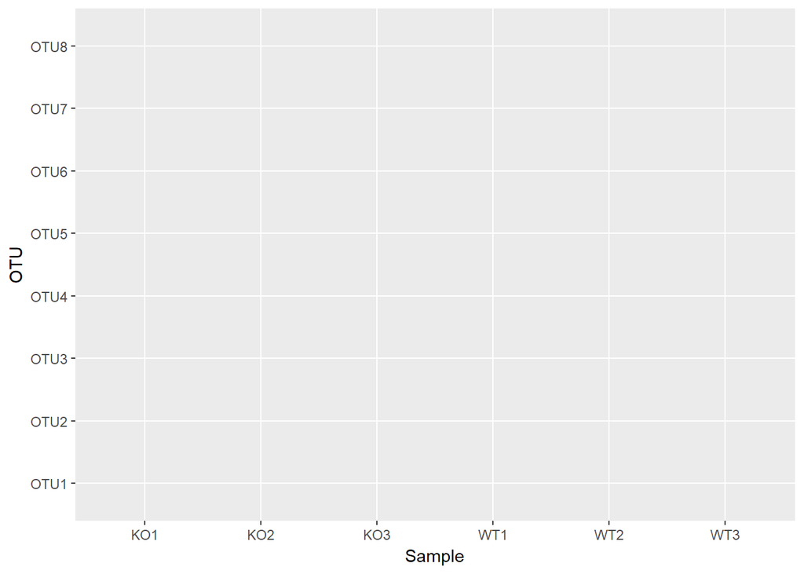

```r
p <- ggplot(data, aes(x=Sample, y=OTU))
p
```

绘制几何属性

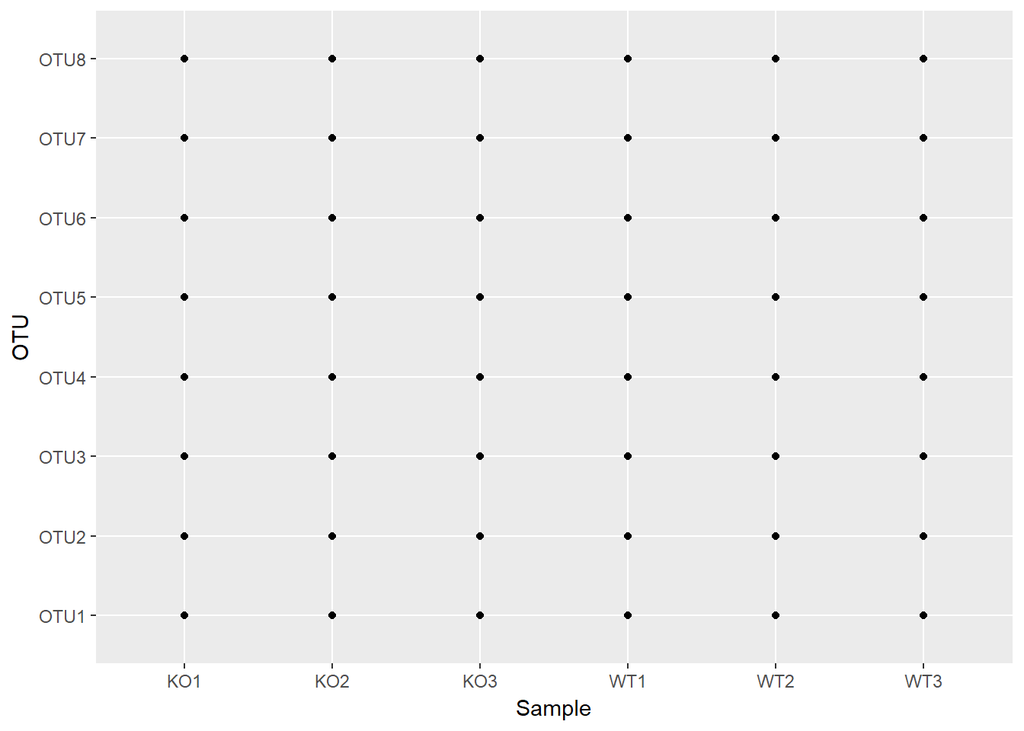

```r
p + geom_point()
```

映射数据到几何形状的属性，如颜色

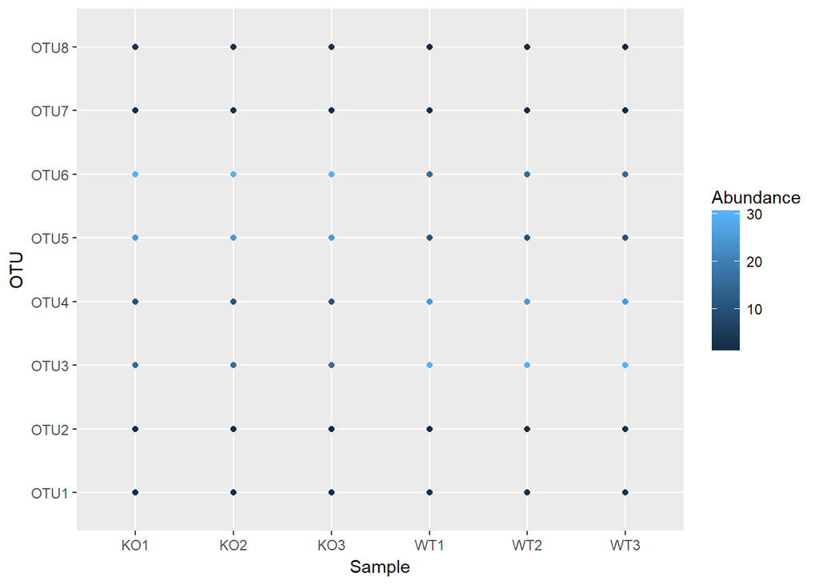

```r
p + geom_point(aes(color=Abundance))
```

映射数据到几何形状的属性，如大小

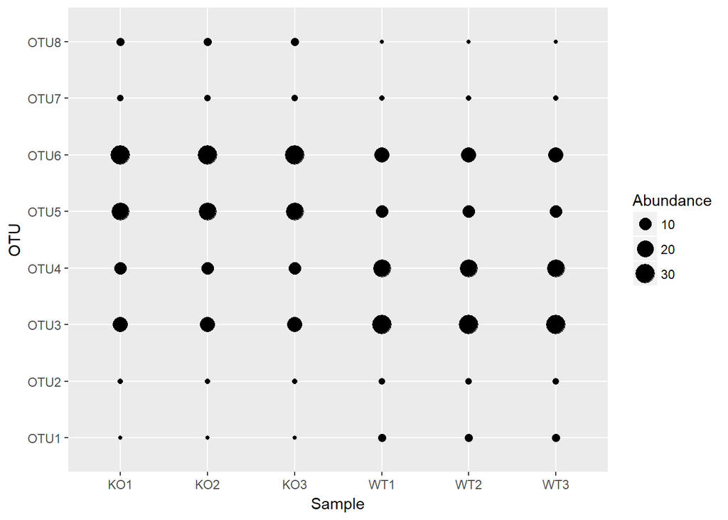

```r
p + geom_point(aes(size=Abundance))
```

自定义颜色

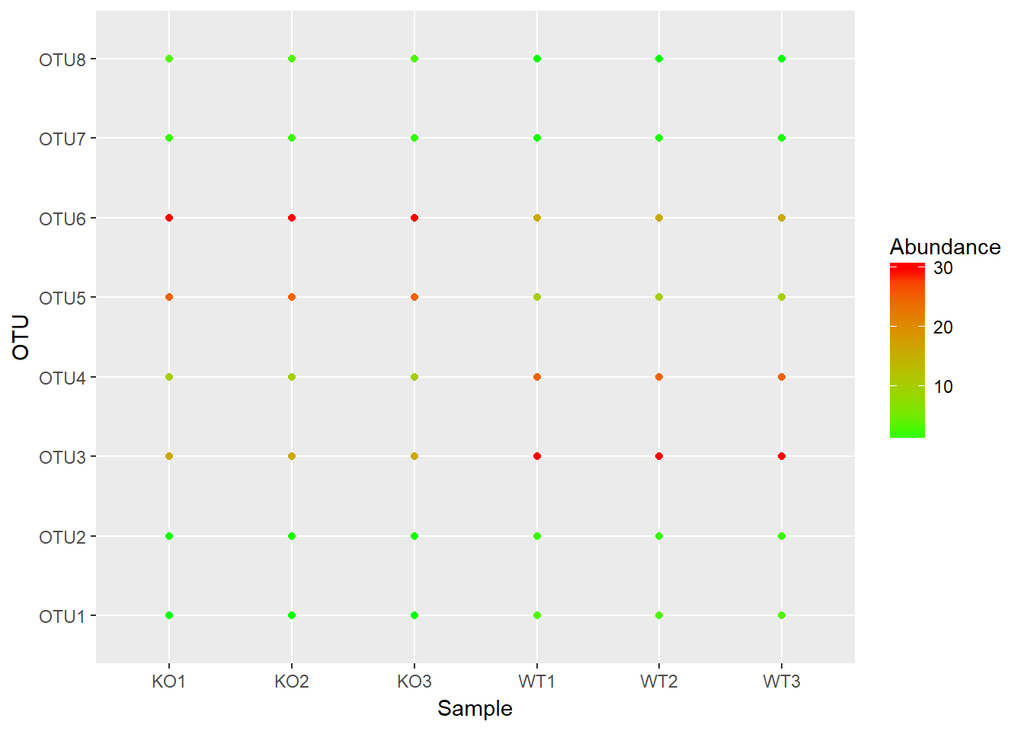

```r
p + geom_point(aes(color=Abundance)) + scale_color_continuous(low="green", high="red")
```

设置主题属性

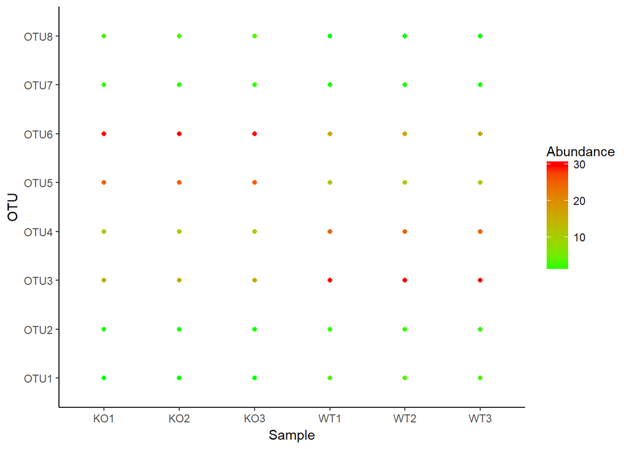

```r
p + geom_point(aes(color=Abundance)) + scale_color_continuous(low="green", high="red") + theme_classic()
```

放大点，并添加文字作为label

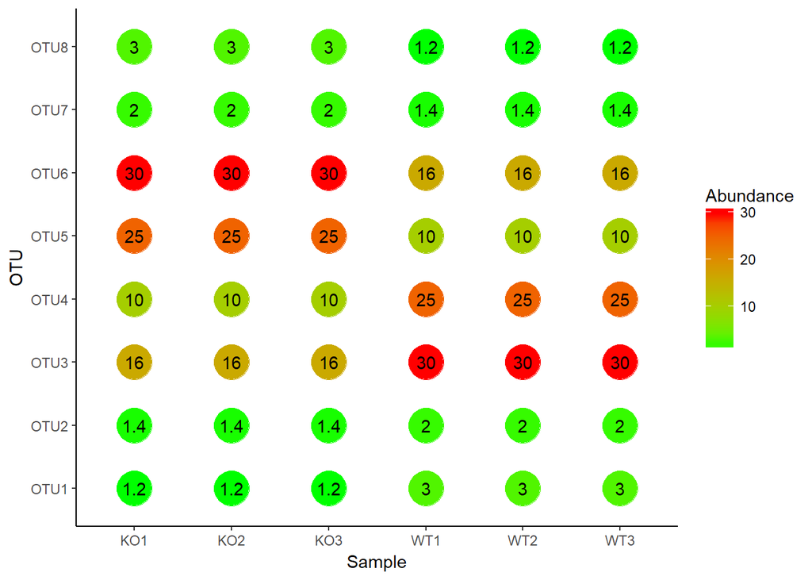

```r
p + geom_point(aes(color=Abundance), size=10) +
                 scale_color_continuous(low="green", high="red") +
                 geom_text(aes(label=Abundance)) +
                 theme_classic()
```

自定义注释

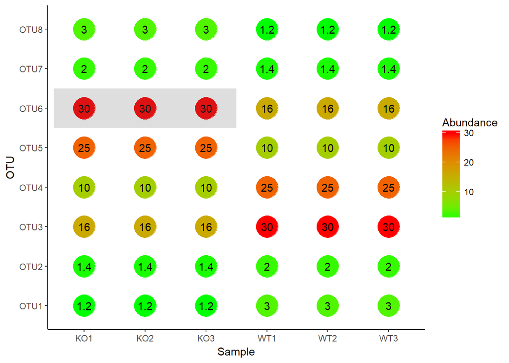

```r
p + geom_point(aes(color=Abundance), size=10) +
  scale_color_continuous(low="green", high="red") +
  geom_text(aes(label=Abundance)) +
  annotate("rect",xmin=0.5, xmax=3.5, ymin=5.5,ymax=6.5,alpha=0.2) +
  theme_classic()
```

绘制热图

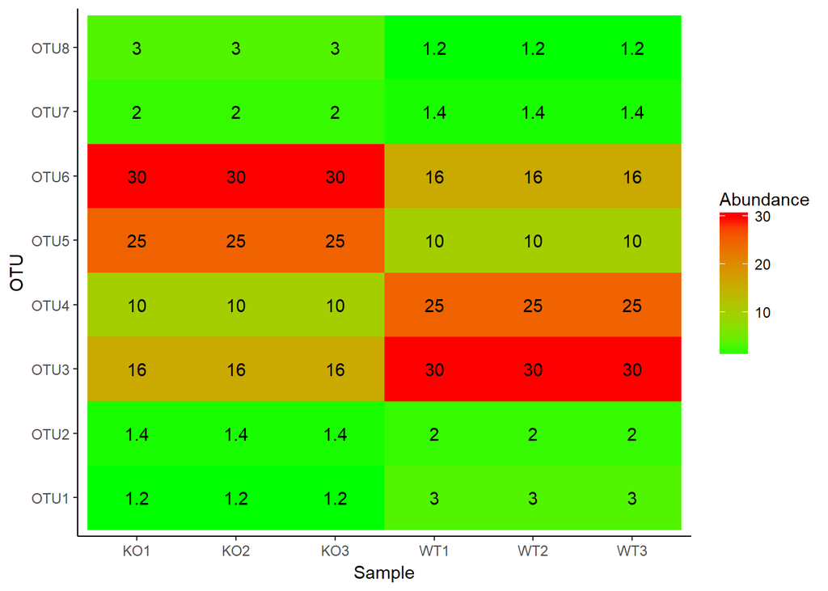

```r
p + geom_tile(aes(fill=Abundance)) +
  scale_fill_continuous(low="green", high="red") +
  geom_text(aes(label=Abundance)) +
  theme_classic()
```

更改横轴的顺序

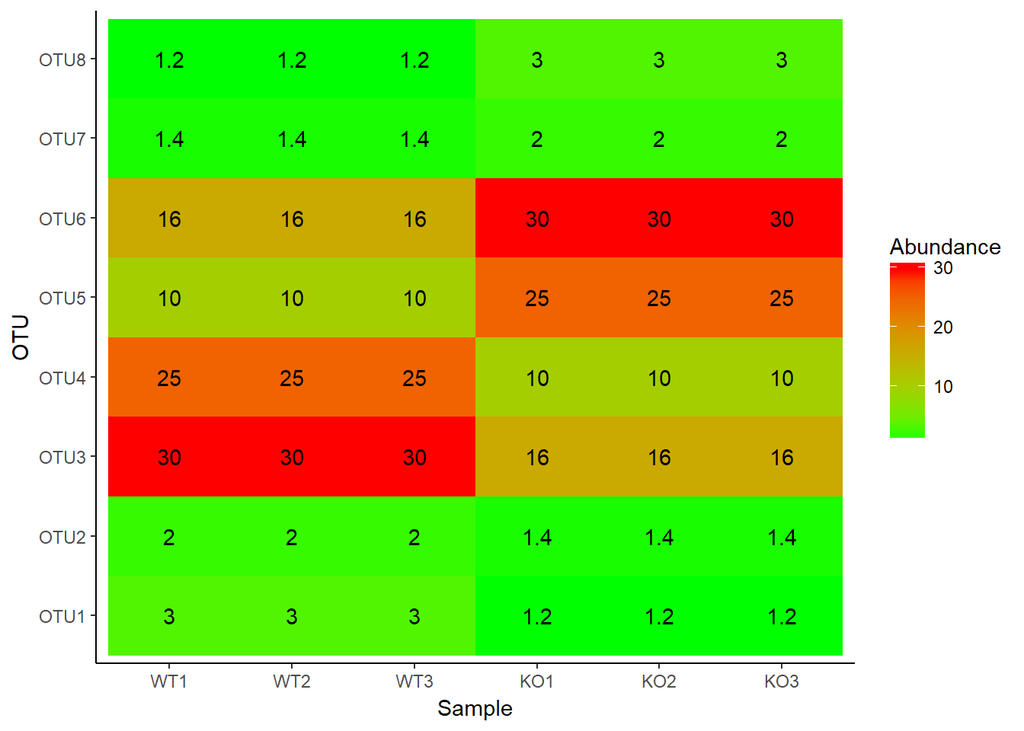

```r
# paste0(rep(c("WT","KO"),each=3), rep(1:3))
data$Sample <- factor(data$Sample,levels=c("WT1","WT2","WT3","KO1","KO2","KO3"), ordered=T)
p <- ggplot(data, aes(x=Sample, y=OTU)) +
  geom_tile(aes(fill=Abundance)) +
  scale_fill_continuous(low="green", high="red") +
  geom_text(aes(label=Abundance)) +
  theme_classic()
p
```

箱线图展示

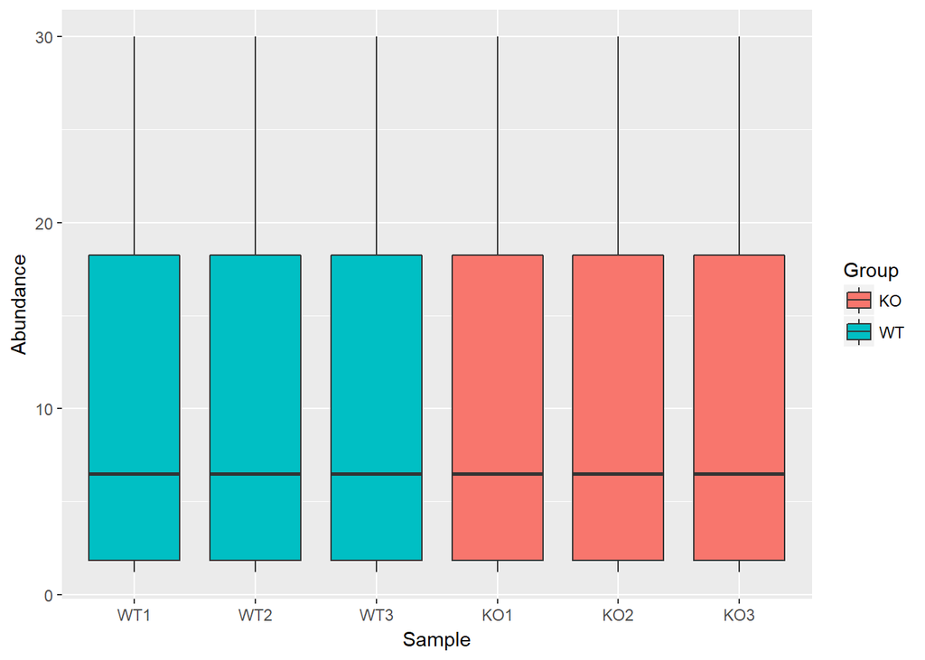

```r
p <- ggplot(data, aes(x=Sample, y=Abundance)) +
  geom_boxplot(aes(fill=Group))
p
```

小提琴图加点的连线

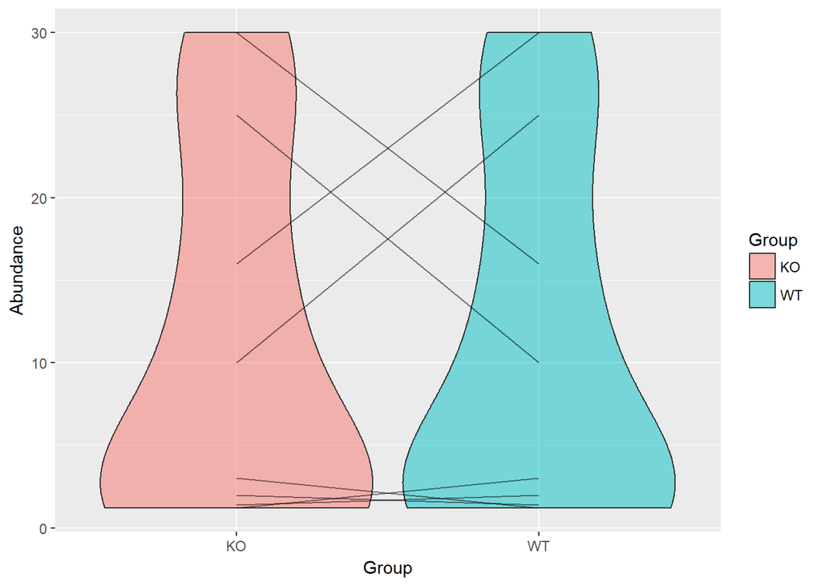

```r
# geom_line把同一个OTU的数据作为一组
p <- ggplot(data, aes(x=Group, y=Abundance)) +
  geom_violin(aes(fill=Group), alpha=0.5) +
  geom_line(aes(group=OTU), alpha=0.5)
p
```

### pheatmap绘制热图

```r
data_matrix = "KO1;KO2;KO3;WT1;WT2;WT3
OTU1;1.2;1.2;1.2;3.0;3.0;3.0
OTU2;1.4;1.4;1.4;2.0;2.0;2.0
OTU3;16.0;16.0;16.0;30.0;30.0;30.0
OTU4;10.0;10.0;10.0;25.0;25.0;25.0
OTU5;25.0;25.0;25.0;10.0;10.0;10.0
OTU6;30.0;30.0;30.0;16.0;16.0;16.0
OTU7;2.0;2.0;2.0;1.4;1.4;1.4
OTU8;3.0;3.0;3.0;1.2;1.2;1.2"

data_matrix <- read.table(text=data_matrix, header=T, row.names=1, sep=";")

head(data_matrix)
```

```
##       KO1  KO2  KO3 WT1 WT2 WT3
## OTU1  1.2  1.2  1.2   3   3   3
## OTU2  1.4  1.4  1.4   2   2   2
## OTU3 16.0 16.0 16.0  30  30  30
## OTU4 10.0 10.0 10.0  25  25  25
## OTU5 25.0 25.0 25.0  10  10  10
## OTU6 30.0 30.0 30.0  16  16  16
```

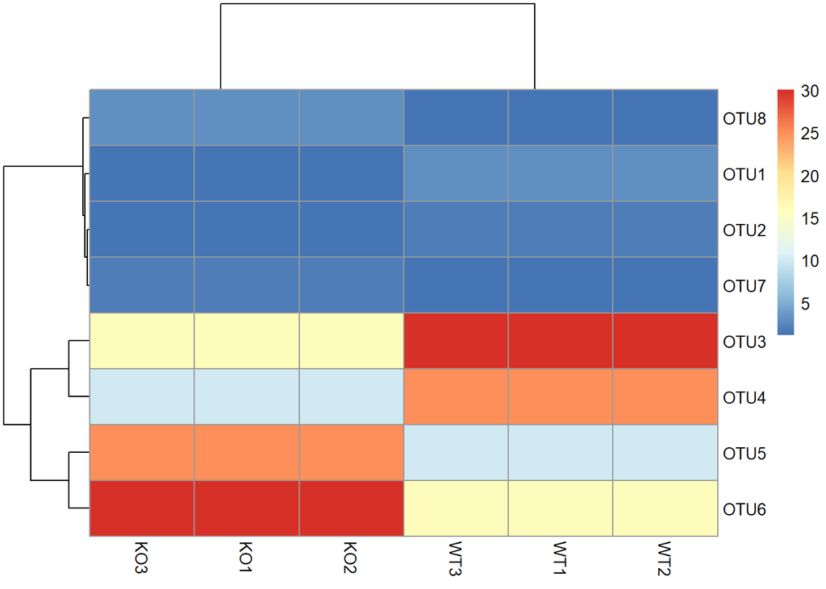

```r
library(pheatmap)
pheatmap(data_matrix)
```

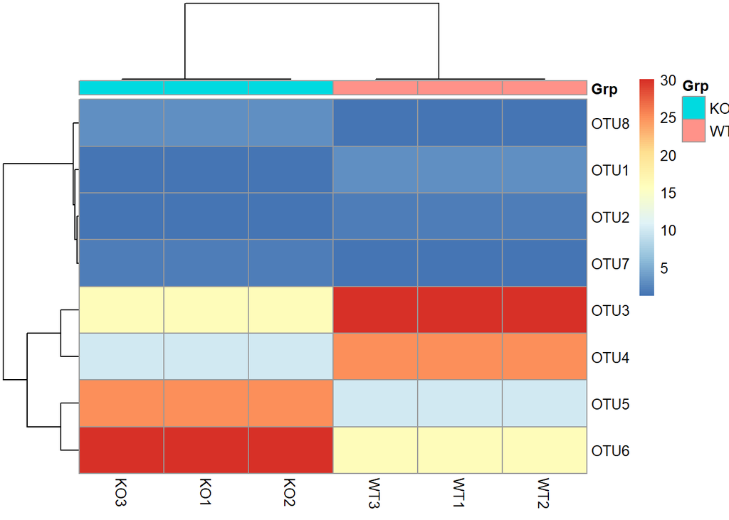

```r
metadata <- "samp;Grp
WT1;WT
WT2;WT
WT3;WT
KO1;KO
KO2;KO
KO3;KO"

metadata <- read.table(text=metadata, header=T, row.names=1, sep=";")

pheatmap(data_matrix, annotation_col = metadata)
```

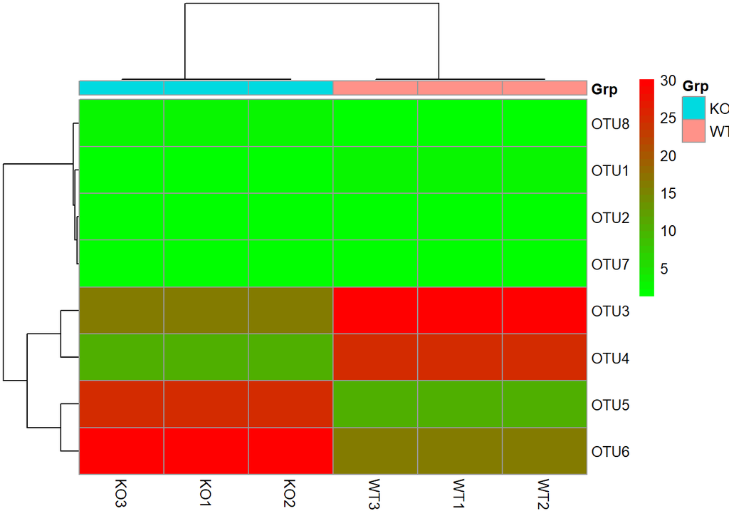

```r
colorL = colorRampPalette(c("green","red"))(30)

pheatmap(data_matrix, annotation_col = metadata, color = colorL)
```

## CheetSheets

https://www.rstudio.com/resources/cheatsheets/

## 参考

- [生信宝典Linux系列](http://mp.weixin.qq.com/s/hEYU80fPf1eD5OWL3fO4Bg)
- [生信宝典R系列](https://mp.weixin.qq.com/s/bsvB1k17Izom2ldgdwXrdg)